# Case Study 3 - Drawing and Predicting Numbers

This is a really fun project!!! We will use TensorFlow to predict hand-drawn digits, build a web application around it and upload it to the Google Cloud.

**TensorFlow**

[TensorFlow](https://www.tensorflow.org/) is an open source library created by Google and designed for high performance numerical computation. It uses a data flow graph to represent mathematical operations that can then easily be computed on local or distributed devices. It offers functionality for computation, math, and advanced modeling. It was released under the Apache 2.0 Open Source License in November of 2015.

**MNIST Dataset**

The MNIST database contains 60,000 training images and 10,000 testing images. It's the "Hello World" of image recognition classification. According to Wikipedia, it is made up of digits written by both high school students and employees from the US Census Bureau.cIt is made up of single, hand-written digits between "0" and "9".

When you install Tensorflow, you will have the ability to download the MNIST directly from the "input_data()" function within "tensorflow.examples.tutorials.mnist" library. This will make training our model that much easier as they have already split the data into training and testing sets. Let's load MNIST in memory and pull out a few samples.

```python
# pip3 install tensorflow
# pip3 install pillow

import tensorflow as tf
from tensorflow.examples.tutorials.mnist import input_data
import numpy as np
import matplotlib.pyplot as plt
```

```
WARNING:tensorflow:From /Library/Frameworks/Python.framework/Versions/3.6/lib/python3.6/site-packages/tensorflow/contrib/learn/python/learn/datasets/base.py:198: retry (from tensorflow.contrib.learn.python.learn.datasets.base) is deprecated and will be removed in a future version.
Instructions for updating:
Use the retry module or similar alternatives.
```

## Load the MNIST data from Tensorflow's tutorials library

```python
# this will take a while the first time you call it as it will download the
# data from the internet - subsequent runs will use the data stored locally
# if you get an SSL error, try fix: "/Applications/Python\ 3.6/Install\ Certificates.command"
# https://github.com/tensorflow/tensorflow/issues/10779
mnist = input_data.read_data_sets("MNIST_data/", one_hot=True)
```

[output not shown]

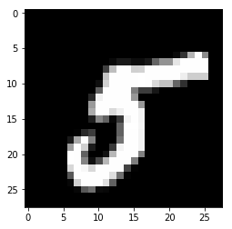

```python
batch = mnist.train.next_batch(1)
sample_digit = batch[0]
sample_digit = sample_digit.reshape(28, 28)
plt.imshow(sample_digit, cmap='gray')
```

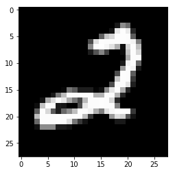

```python
first_digit = mnist.train.images[0]
first_digit = np.array(first_digit, dtype='float')
first_digit = first_digit.reshape((28, 28))
plt.imshow(first_digit, cmap='gray')
```

```python
mnist.train.labels[0]
```

```
array([0., 0., 1., 0., 0., 0., 0., 0., 0., 0.])
```

### Access the label in legible format

```python
np.argmax(mnist.train.labels[0])
```

```
2
```

# Tensorflow Modeling

Based on the following tutorial (but with some modefications to handle saving of model for later re-use): https://www.tensorflow.org/versions/r1.1/get_started/mnist/pros

```python
import os
import tensorflow as tf
from tensorflow.examples.tutorials.mnist import input_data
mnist = input_data.read_data_sets('MNIST_data', one_hot=True)

# The file path to save the data
save_file = os.path.join(os.getcwd(), 'model.ckpt')

x = tf.placeholder(tf.float32, shape=[None, 784])
y_ = tf.placeholder(tf.float32, shape=[None, 10])

def weight_variable(shape):
  initial = tf.truncated_normal(shape, stddev=0.1)
  return tf.Variable(initial)

def bias_variable(shape):
  initial = tf.constant(0.1, shape=shape)
  return tf.Variable(initial)

def conv2d(x, W):
  return tf.nn.conv2d(x, W, strides=[1, 1, 1, 1], padding='SAME')

def max_pool_2x2(x):
  return tf.nn.max_pool(x, ksize=[1, 2, 2, 1],
                        strides=[1, 2, 2, 1], padding='SAME')

# First convolutional layer
W_conv1 = weight_variable([5, 5, 1, 32])
b_conv1 = bias_variable([32])
x_image = tf.reshape(x, [-1, 28, 28, 1])
h_conv1 = tf.nn.relu(conv2d(x_image, W_conv1) + b_conv1)
h_pool1 = max_pool_2x2(h_conv1)

# Second convolutional layer
W_conv2 = weight_variable([5, 5, 32, 64])
b_conv2 = bias_variable([64])
h_conv2 = tf.nn.relu(conv2d(h_pool1, W_conv2) + b_conv2)
h_pool2 = max_pool_2x2(h_conv2)

# Densely Connected Layer
W_fc1 = weight_variable([7 * 7 * 64, 1024])
b_fc1 = bias_variable([1024])

h_pool2_flat = tf.reshape(h_pool2, [-1, 7*7*64])
h_fc1 = tf.nn.relu(tf.matmul(h_pool2_flat, W_fc1) + b_fc1)

# Dropout
keep_prob = tf.placeholder(tf.float32)
h_fc1_drop = tf.nn.dropout(h_fc1, keep_prob)

# Readout Layer
W_fc2 = weight_variable([1024, 10])
b_fc2 = bias_variable([10])

y_conv = tf.nn.softmax(tf.matmul(h_fc1_drop, W_fc2) + b_fc2, name='y')
cross_entropy = tf.reduce_mean(-tf.reduce_sum(y_ * tf.log(y_conv), reduction_indices=[1]))

train_step = tf.train.AdamOptimizer(1e-4).minimize(cross_entropy)
correct_prediction = tf.equal(tf.argmax(y_conv, 1), tf.argmax(y_, 1))
accuracy = tf.reduce_mean(tf.cast(correct_prediction, tf.float32))

# Training steps
with tf.Session() as sess:
    sess.run(tf.global_variables_initializer())

    max_steps = 2000 # recommended is 20000
    for step in range(max_steps):
        batch_xs, batch_ys = mnist.train.next_batch(50)
        if (step % 100) == 0:
            print(step, sess.run(accuracy, feed_dict={x: mnist.test.images, y_: mnist.test.labels, keep_prob: 1.0}))
        sess.run(train_step, feed_dict={x: batch_xs, y_: batch_ys, keep_prob: 0.5})
    print(max_steps, sess.run(accuracy, feed_dict={x: mnist.test.images, y_: mnist.test.labels, keep_prob: 1.0}))

    saver = tf.train.Saver()
    save_path = saver.save(sess, save_file)
    print ("Model saved in file: ", save_path)
```

```
Extracting MNIST_data/train-images-idx3-ubyte.gz
Extracting MNIST_data/train-labels-idx1-ubyte.gz
Extracting MNIST_data/t10k-images-idx3-ubyte.gz
Extracting MNIST_data/t10k-labels-idx1-ubyte.gz
0 0.1647
100 0.8343
200 0.899
300 0.9199
400 0.9347
500 0.9411
600 0.9454
700 0.9501
800 0.9541
900 0.9547
1000 0.9598
1100 0.9624
1200 0.965
1300 0.9662
1400 0.9668
1500 0.9694
1600 0.9703
1700 0.9705
1800 0.9712
1900 0.9742
2000 0.9746
Model saved in file:  /Users/manuel/Documents/class/applied-data-science-web-apps/Case Study 3 - Drawing and Predicting Numbers/model.ckpt
```

**Want to learn more about DNNs?**

playground.tensorflow.org

## Loading up a saved and trained model to run our predictions

We need to rebuild the plumbing but don't need to load the data or run the model, simply feed the checkpoints to the saver function. To test the model we will add a PNG image: 'mnist_5.png', so we're looking for the model to predict "5"

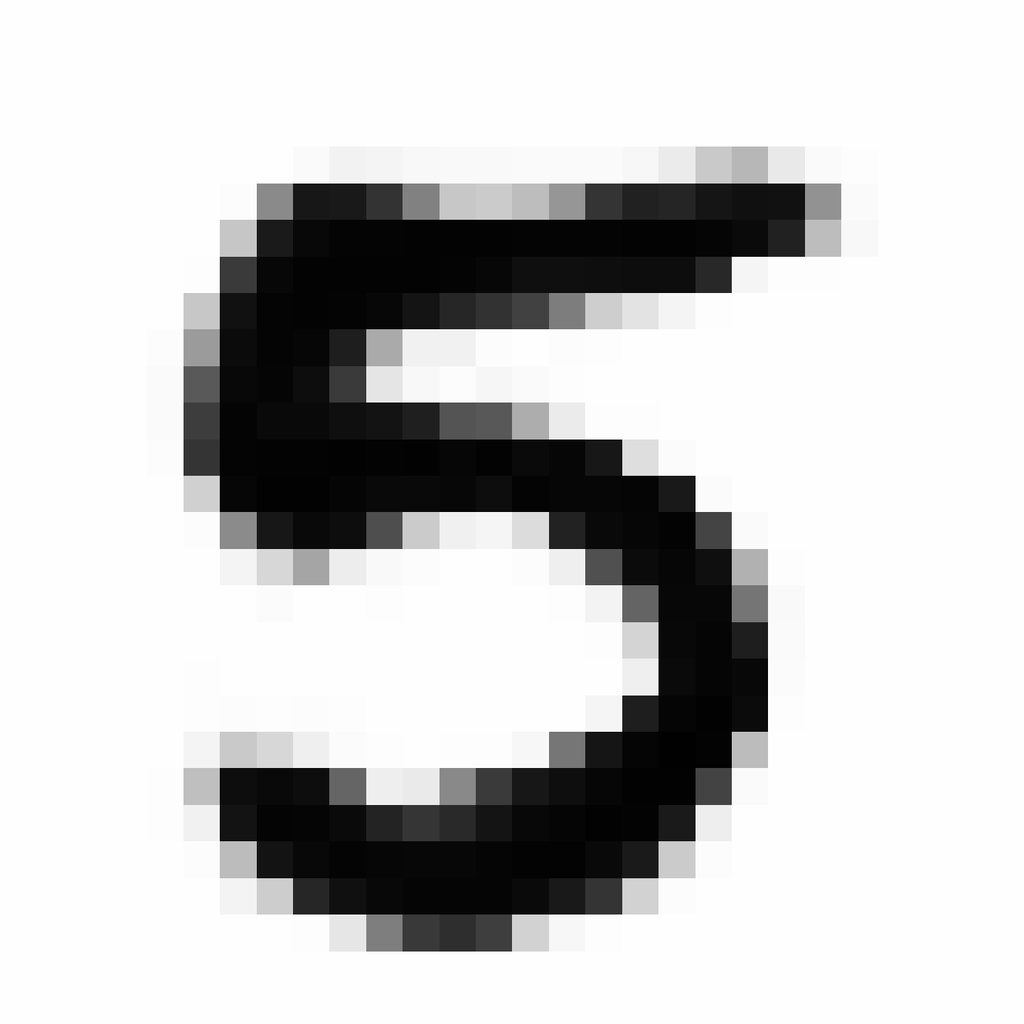

```python
from IPython.display import Image
Image(filename="mnist_5.png")
```

```python
import os
save_file = os.path.join(os.getcwd(), 'model.ckpt')
import tensorflow as tf
from PIL import Image
import sys
import matplotlib.pyplot as plt
import numpy as np

# restore the saved session
tf.reset_default_graph()

# set all variables needed like in orginal model
x = tf.placeholder(tf.float32, shape=[None, 784])
y_ = tf.placeholder(tf.float32, shape=[None, 10])

def weight_variable(shape):
  initial = tf.truncated_normal(shape, stddev=0.1)
  return tf.Variable(initial)

def bias_variable(shape):
  initial = tf.constant(0.1, shape=shape)
  return tf.Variable(initial)

def conv2d(x, W):
  return tf.nn.conv2d(x, W, strides=[1, 1, 1, 1], padding='SAME')

def max_pool_2x2(x):
  return tf.nn.max_pool(x, ksize=[1, 2, 2, 1],
                        strides=[1, 2, 2, 1], padding='SAME')

# First convolutional layer
W_conv1 = weight_variable([5, 5, 1, 32])
b_conv1 = bias_variable([32])
x_image = tf.reshape(x, [-1, 28, 28, 1])
h_conv1 = tf.nn.relu(conv2d(x_image, W_conv1) + b_conv1)
h_pool1 = max_pool_2x2(h_conv1)

# Second convolutional layer
W_conv2 = weight_variable([5, 5, 32, 64])
b_conv2 = bias_variable([64])

h_conv2 = tf.nn.relu(conv2d(h_pool1, W_conv2) + b_conv2)
h_pool2 = max_pool_2x2(h_conv2)

# Densely Connected Layer
W_fc1 = weight_variable([7 * 7 * 64, 1024])
b_fc1 = bias_variable([1024])

h_pool2_flat = tf.reshape(h_pool2, [-1, 7*7*64])
h_fc1 = tf.nn.relu(tf.matmul(h_pool2_flat, W_fc1) + b_fc1)

# Dropout
keep_prob = tf.placeholder(tf.float32)
h_fc1_drop = tf.nn.dropout(h_fc1, keep_prob)

# Readout Layer
W_fc2 = weight_variable([1024, 10])
b_fc2 = bias_variable([10])

y_conv = tf.nn.softmax(tf.matmul(h_fc1_drop, W_fc2) + b_fc2, name='y')

# fix image to be in abide by our model's format requirements
img = Image.open('mnist_5.png')
img = img.resize([28,28])
corrected_img = Image.new("RGBA", (28, 28), "white")
corrected_img.paste(img, (0,0), img)
corrected_img = np.asarray(corrected_img)
# remove color dimensions
corrected_img = corrected_img[:, :, 0]
corrected_img = np.invert(corrected_img)
# flatten
corrected_img = corrected_img.reshape([784])
# center around 0-1
img = np.asarray(corrected_img, dtype=np.float32) / 255.

# Training steps
saver = tf.train.Saver()
with tf.Session() as sess:
    sess.run(tf.global_variables_initializer())

    saver.restore(sess, save_file)
    print("Model restored.")
    print(sess.run(tf.argmax(y_conv,1), feed_dict={x: [img], keep_prob: 1.0}))
```

```
INFO:tensorflow:Restoring parameters from /Users/manuel/Documents/class/applied-data-science-web-apps/Case Study 3 - Drawing and Predicting Numbers/model.ckpt
Model restored.
[5]
```

```python
y_conv
```

```
<tf.Tensor 'y:0' shape=(?, 10) dtype=float32>
```

## Prototyping Our Model Using Flask

Here we need a certain amount of files in order to get the model to work properly. As we are loading the model from a saved checkpoint file we need the latest checkpoints in the main folder as shown below.

```
Create a folder called 'drawing_and_predicting_numbers' and create the following structure:

drawing_and_predicting_numbers/
├── main.py
├── model.ckpt.data-00000-of-00001
├── model.ckpt.index
├── model.ckpt.meta
├── static/
    └── images/
        ├── right.png
        ├── left.png
        └── top.png
└── templates/
        └── predict_number.html
```

Create a Python file called "main.py":

```
#!/usr/bin/env python
from flask import Flask, render_template, flash, request, jsonify, Markup
import logging, sys
import matplotlib
matplotlib.use('Agg')
import matplotlib.pyplot as plt
import io, base64, os
import numpy as np
from array import array
from base64 import decodestring
from PIL import Image
import tensorflow as tf

# global variables
app = Flask(__name__)

# full path to check point
tensorflow_ckpt_file = 'model.ckpt'


def GetDigitPrediction(img):
    # restore the saved session

    def weight_variable(shape):
      initial = tf.truncated_normal(shape, stddev=0.1)
      return tf.Variable(initial)

    def bias_variable(shape):
      initial = tf.constant(0.1, shape=shape)
      return tf.Variable(initial)

    def conv2d(x, W):
      return tf.nn.conv2d(x, W, strides=[1, 1, 1, 1], padding='SAME')

    def max_pool_2x2(x):
      return tf.nn.max_pool(x, ksize=[1, 2, 2, 1],
                            strides=[1, 2, 2, 1], padding='SAME')


    # Input layer
    tf.reset_default_graph()
    x  = tf.placeholder(tf.float32, [None, 784], name='x')
    y_ = tf.placeholder(tf.float32, [None, 10],  name='y_')
    x_image = tf.reshape(x, [-1, 28, 28, 1])

    # Convolutional layer 1
    W_conv1 = weight_variable([5, 5, 1, 32])
    b_conv1 = bias_variable([32])

    h_conv1 = tf.nn.relu(conv2d(x_image, W_conv1) + b_conv1)
    h_pool1 = max_pool_2x2(h_conv1)

    # Convolutional layer 2
    W_conv2 = weight_variable([5, 5, 32, 64])
    b_conv2 = bias_variable([64])

    h_conv2 = tf.nn.relu(conv2d(h_pool1, W_conv2) + b_conv2)
    h_pool2 = max_pool_2x2(h_conv2)

    # Fully connected layer 1
    h_pool2_flat = tf.reshape(h_pool2, [-1, 7*7*64])

    W_fc1 = weight_variable([7 * 7 * 64, 1024])
    b_fc1 = bias_variable([1024])

    h_fc1 = tf.nn.relu(tf.matmul(h_pool2_flat, W_fc1) + b_fc1)

    # Dropout
    keep_prob  = tf.placeholder(tf.float32)
    h_fc1_drop = tf.nn.dropout(h_fc1, keep_prob)

    # Fully connected layer 2 (Output layer)
    W_fc2 = weight_variable([1024, 10])
    b_fc2 = bias_variable([10])

    y = tf.nn.softmax(tf.matmul(h_fc1_drop, W_fc2) + b_fc2, name='y')

    # Evaluation functions
    cross_entropy = tf.reduce_mean(-tf.reduce_sum(y_ * tf.log(y), reduction_indices=[1]))

    correct_prediction = tf.equal(tf.argmax(y, 1), tf.argmax(y_, 1))
    accuracy = tf.reduce_mean(tf.cast(correct_prediction, tf.float32), name='accuracy')

    # Training algorithm
    train_step = tf.train.AdamOptimizer(1e-4).minimize(cross_entropy)


    # Training steps
    saver = tf.train.Saver()
    with tf.Session() as sess:
        sess.run(tf.global_variables_initializer())

        saver.restore(sess, tensorflow_ckpt_file)
        classification = sess.run(tf.argmax(y, 1), feed_dict={x: [img], keep_prob: 1.0})
        return(classification[0])


@app.route("/", methods=['POST', 'GET'])
def DrawAndPredict():
    drawing_data = ''
    prediction = '?'

    # set up page with blanks
    return render_template('predict_number.html',
        drawing_data = drawing_data,
        prediction = prediction)

@app.route('/background_process', methods=['POST', 'GET'])
def background_process():
    prediction = -1
    try:
        drawing_data_original = request.form['drawing_data']
        user_drawn_image = drawing_data_original.split(',')[1]
        if len(user_drawn_image) > 0:
            buf = io.BytesIO(base64.b64decode(user_drawn_image))
            img = Image.open(buf)
            img = img.resize([28,28])

            # these are transparent images so apply a white background
            corrected_img = Image.new("RGBA", (28, 28), "white")
            corrected_img.paste(img, (0,0), img)
            corrected_img = np.asarray(corrected_img)
            # remove color dimensions
            corrected_img = corrected_img[:, :, 0]
            corrected_img = np.invert(corrected_img)
            # flatten
            corrected_img = corrected_img.reshape([784])
            # center around 0-1
            corrected_img = np.asarray(corrected_img, dtype=np.float32) / 255.
            prediction = int(GetDigitPrediction(corrected_img))
    except:
        # something didn't go right
        e = sys.exc_info()[0]
        prediction = e
        message = "Cannot find that location, please try again"

    return jsonify({'prediction':prediction})


if __name__=='__main__':
    app.run(debug=True)
```

Create the 'predict_number.html' file:

```
<!DOCTYPE html>
<html>
<head>

    <meta name="viewport" content="width=device-width, initial-scale=1">
    <meta charset="UTF=8">
    <title>Guess My Number</title>

    <script src="//ajax.googleapis.com/ajax/libs/jquery/1.9.1/jquery.min.js"></script>
    <link rel="stylesheet" href="//netdna.bootstrapcdn.com/bootstrap/3.0.3/css/bootstrap-theme.min.css">
    <link rel="stylesheet" href="//netdna.bootstrapcdn.com/bootstrap/3.0.3/css/bootstrap.min.css">
    <script src="//netdna.bootstrapcdn.com/bootstrap/3.0.3/js/bootstrap.min.js"></script>

    <script type="text/javascript">
    var canvas, ctx, flag = false,
        prevX = 0,
        currX = 0,
        prevY = 0,
        currY = 0,
        dot_flag = false;

    var x = "black",
        y = 20;

    function init() {
        canvas = document.getElementById('canvas_area');
        ctx = canvas.getContext("2d");
        w = canvas.width;
        h = canvas.height;

        canvas.addEventListener("mousemove", function (e) {
            findxy('move', e)
        }, false);
        canvas.addEventListener("mousedown", function (e) {
            findxy('down', e)
        }, false);
        canvas.addEventListener("mouseup", function (e) {
            findxy('up', e)
        }, false);
        canvas.addEventListener("mouseout", function (e) {
            findxy('out', e)
        }, false);

    }

    function draw() {
        ctx.beginPath();
        ctx.moveTo(prevX, prevY);
        ctx.lineTo(currX, currY);
        ctx.strokeStyle = x;
        ctx.lineWidth = y;
        ctx.shadowBlur = 2;
        ctx.lineJoin = ctx.lineCap = 'round';
        ctx.stroke();
        ctx.closePath();
    }

    function erase() {
        ctx.clearRect(0, 0, w, h);
        predicted_digit.innerHTML = '?';
    }

    function findxy(res, e) {
        if (res == 'down') {
            prevX = currX;
            prevY = currY;
            currX = e.clientX - canvas.offsetLeft;
            currY = e.clientY - canvas.offsetTop;

            flag = true;
            dot_flag = true;
            if (dot_flag) {
                ctx.beginPath();
                ctx.fillStyle = x;
                ctx.fillRect(currX, currY, 2, 2);
                ctx.closePath();
                dot_flag = false;
            }
        }
        if (res == 'up' || res == "out") {
            flag = false;
        }
        if (res == 'move') {
            if (flag) {
                prevX = currX;
                prevY = currY;
                currX = e.clientX - canvas.offsetLeft;
                currY = e.clientY - canvas.offsetTop;
                draw();
            }
        }
    }

    function SetBrushSize() {
        y = document.getElementById("brush_select").value;

    }

    </script>



    <body onload="init()">



        <table border="0" cellpadding="0" cellspacing="0">
             <tr>
                <td colspan="3" align="center" style='background-color: black;'>
                    <H1><font color="gold">Machine Learning Web Applications <BR>Master Class</font></H1>
                    <H3><font color="darkyellow">Draw a digit between 0 and 9 and <BR>click 'Predict' to have the model divine it!</font></H3></td>
            </tr>
            <tr>
                <td colspan="3"><img src="static/images/top.png" alt="top" width="734" height="329"></td>
            </tr>
            <tr>
                <td align="left"><img src="static/images/left.png" alt="top" width="209" height="332"></td>
                <td><canvas id="canvas_area" width="280" height="280"
                    style="position:relative;top:0%;left:0%;border:2px solid; background-color: white"></canvas></td>
                <td align="right"><img src="static/images/right.png" alt="top" width="209" height="332"></td>
            </tr>
             <tr>
                <td></td>
                <td>
                    <input type="button" value="Predict" id="btn" size="30" onclick="fetchdata()">
                    <input type="button" value="clear" id="clr" size="23" onclick="erase()">
                    <label>Brush Size:</label>
                    <select id="brush_select" onchange="SetBrushSize()">
                          <option value="20">20</option>
                          <option value="30" selected>30</option>
                          <option value="50">50</option>
                          <option value="80">80</option>
                        </select>
                    </td>
                <td></td>
            </tr>
        </table>

        <label id='predicted_digit' name='predicted_digit' style="font-size:32px; position:absolute; top:200px; left:360px; width:30px;height:50px;border:2px solid;background-color: lightgreen"> {{prediction}}
        </label>


    </body>


    <script>
    function update_dashboard(prediction){
        predicted_digit.innerHTML = prediction;
    }

    function fetchdata()
    {
        $.ajax({
            type : "POST",
            url:'{{ url_for('background_process') }}',
            data:{'drawing_data': canvas_area.toDataURL()},
            success: function(data){
                update_dashboard(data.prediction);
            }
        });
    }

    </script>

    </html>
```

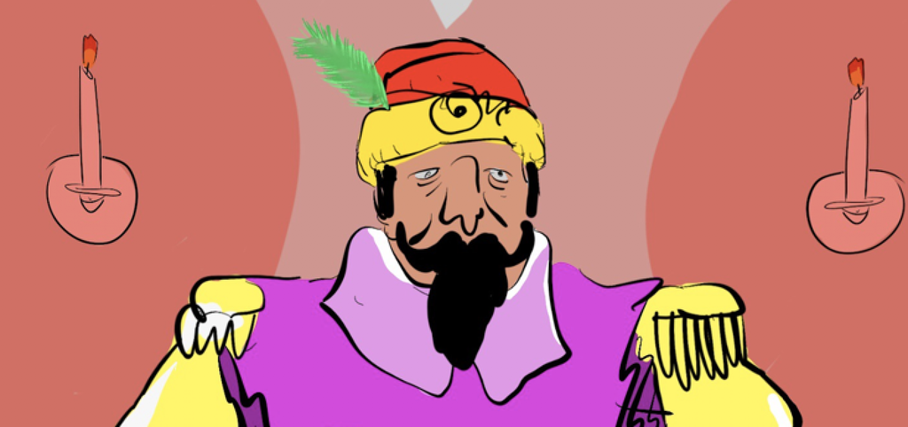

```python
from IPython.display import Image
Image(filename="static/images/top.png")
```

[figure not shown]

```python
Image(filename="static/images/right.png")
```

[figure not shown]

```python
Image(filename="static/images/left.png")
```

## Notes on the Canvas Drawing Tool

The canvas is a critical part of the application as it will allow anyone, no matter the skill level, to get exposure to the MNIST data set, character-recognition, and convolutional modeling.

The canvas is part of HTML5 (for more information on this cool feature, see https://www.w3schools.com/html/html5_canvas.asp) and allows the creation of a space where a user can interact and create drawings on a web page.

## From Canvas to TensorFlow

When a visitor hits the "Predict" button, it calls the "toDataURL()" function of the canvas HTML5 control.

This translates whatever data is contained within the canvas tags into text representation of the image.

The HTMLCanvasElement.toDataURL() method returns a data URI containing a representation of the image in the format specified by the type parameter (defaults to PNG). The returned image is in a resolution of 96 dpi .

- MDN Web Docs

## Testing on New Hand-written Digits

We need to be able to pass new hand-written digits to the model for prediction. The difference between testing using the MNIST data set and a real image is that the MNIST data has already been processed for us. We therefore need to apply the same processing on the new images, so it can be compatible with our trained model's. Imagine you create an image file with a digit, this is how you would pass it to the model. We leverage the PIL and Numpy Python libraries to perform most of the image processing.

# Google Cloud Flexible App Engine

[figure not shown]

```python
Image(filename="google-cloud-logo.png")
```

Create the following three files and an account on Google Cloud (this is free for new users along with a $300 credit use)

### Create an app.yaml file and copy the following code:

```
runtime: python
env: flex
entrypoint: gunicorn -b :$PORT main:app

runtime_config:
  python_version: 3

# This sample incurs costs to run on the App Engine flexible environment.
# The settings below are to reduce costs during testing and are not appropriate
# for production use. For more information, see:
# https://cloud.google.com/appengine/docs/flexible/python/configuring-your-app-with-app-yaml
manual_scaling:
  instances: 1
resources:
  cpu: 1
  memory_gb: 3
  disk_size_gb: 20
```

### Create a requirements.txt file and copy the following text:

```
gunicorn
tensorflow
flask
matplotlib
Pillow
```

### Create an appengine_config.py file and copy the following code:

```
from google.appengine.ext import vendor

# Add any libraries installed in the "lib" folder
vendor.add('lib')
```

### Here are the high-level steps, refer to video for full tutorial:

- Create a project if you don't already have a default project
- Access Google Cloud Shell
- Create directory (mkdir drawing_and_predicting_numbers)

```
$ mkdir drawing_and_predicting_numbers
$ cd drawing_and_predicting_numbers
```

- Zip and upload all the files under drawing_and_predicting_numbers directory

```
$ mv ../Archive.zip Archive.zip
$ unzip Archive.zip
```

- Create and install the libraries

```
$ sudo pip3 install -t lib -r requirements.txt
```

- Finally, deploy your web application!!!

```
gcloud app deploy app.yaml
```

You will be asked a question:

```
Please choose the region where you want your App Engine application
located:

[13] us-west2      (supports standard and flexible)
```

And accept the final confirmation:

```
Creating App Engine application...
```

## Once you are done - don't forget to delete your clould app!